# Coordinate Systems

Pritpal Singh

2023-09-09

```r
library(ggplot2)
```

Coordinate Systems are probably the most complicated part of **ggplot2**. The default coordinate system is the Cartesian Coordinate system where the x and y position act independently to find the location of each point. There are number of other coordinate systems that are occasionally helpful.

1. `coord_flip()` switches the x- and y-axes. This is useful if we want horizontal boxplots. It’s also useful for long labels – it’s hard to get them to fit without overlapping on the x-axis.

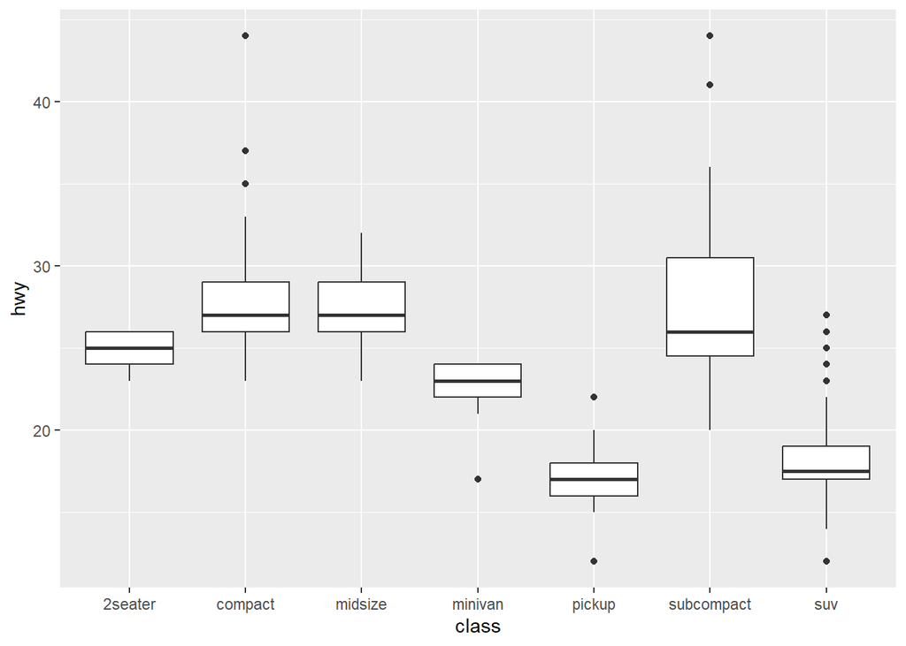

   ```r
   ggplot(data = mpg, mapping = aes(x = class, y = hwy)) +
     geom_boxplot()
   ```

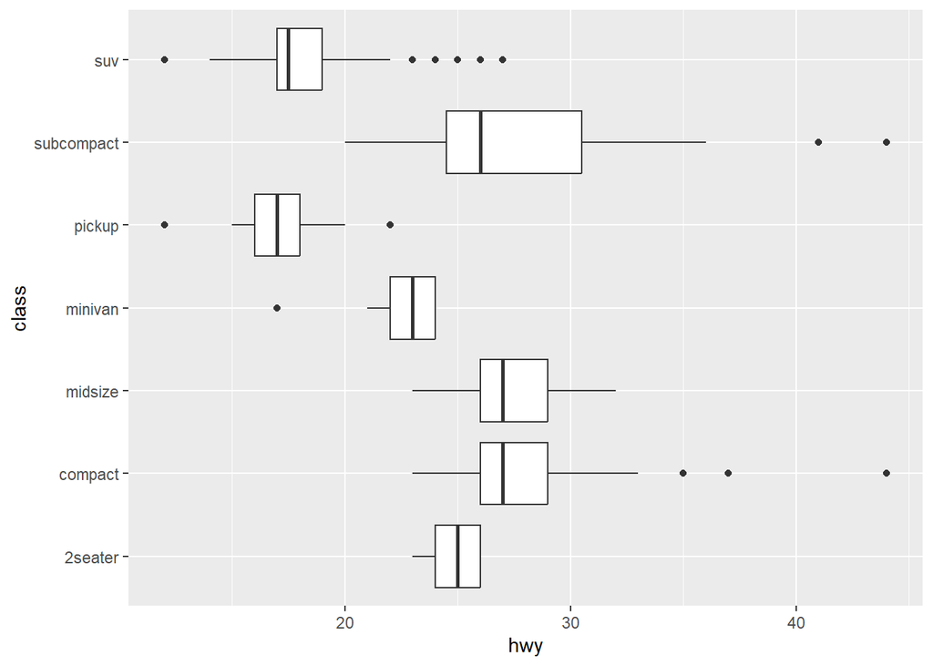

   ```r
   ggplot(data = mpg, mapping = aes(x = class, y = hwy)) +
     geom_boxplot() +
     coord_flip()
   ```

2. `coord_quickmap()` sets the aspect ratio correctly for maps. This is very important if we are plotting spatial data with **ggplot2**.

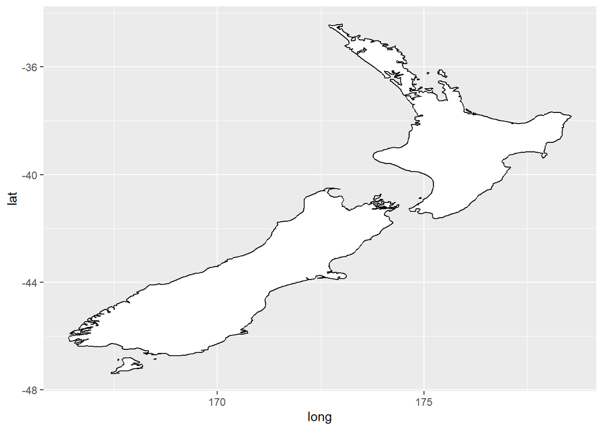

   ```r
   nz <- map_data("nz")

   ggplot(nz, aes(long, lat, group = group)) +
    geom_polygon(fill = "white", color = "black")
   ```

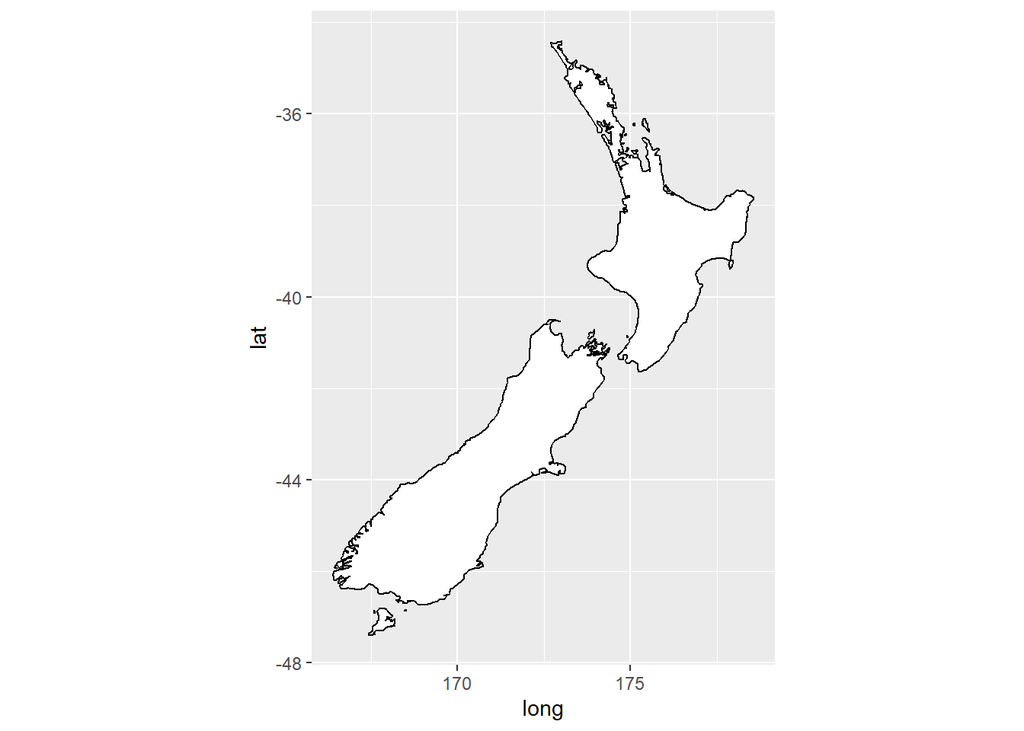

   ```r
   ggplot(nz, aes(long, lat, group = group)) +
    geom_polygon(fill = "white", color = "black") +
    coord_quickmap()
   ```

3. `coord_polar()` uses polar coordinates. Polar coordinates reveal an interesting connection between a bar chart and a Coxcomb chart.

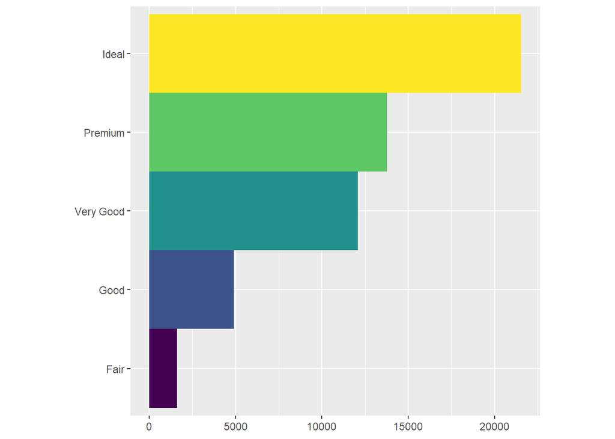

   ```r
   bar <- ggplot(data = diamonds) +
     geom_bar(
       mapping = aes(x = cut, fill = cut),
       show.legend = FALSE,
       width = 1
     ) +
     theme(aspect.ratio = 1) +
     labs(x = NULL, y = NULL)

   bar + coord_flip()
   ```

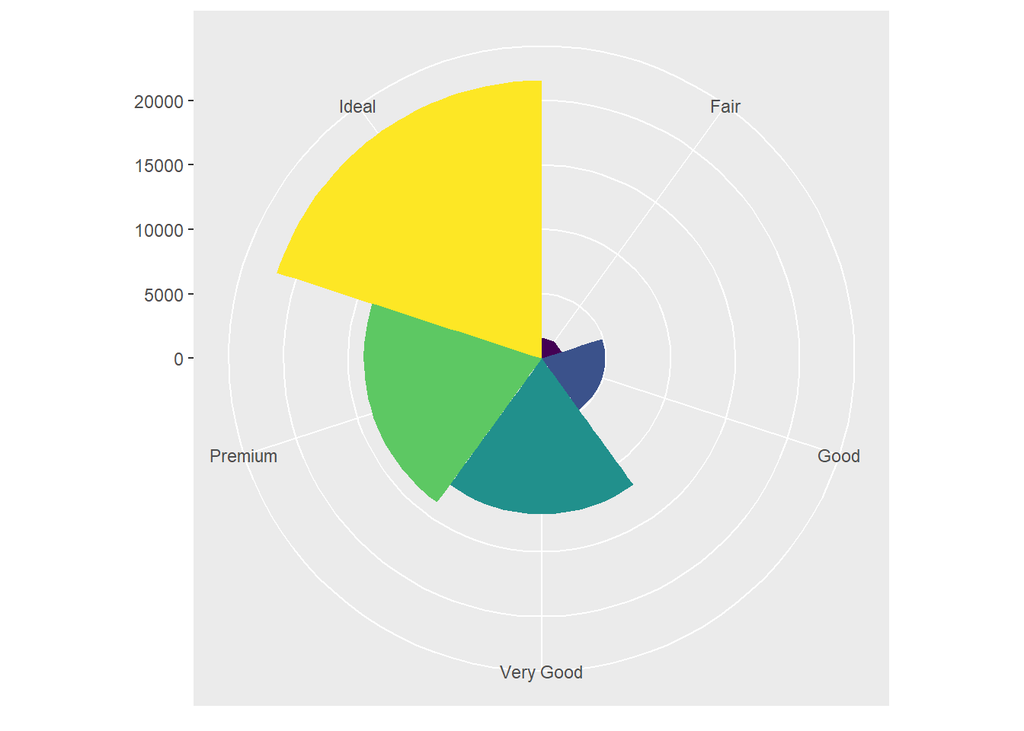

   ```r
   bar + coord_polar()
   ```

## Exercises

1. Turn a stacked bar chart into a pie chart using `coord_polar()`.
2. What does `labs()` do? Read the documentation.
3. What’s the difference between `coord_quickmap()` and `coord_map()`?
4. What does the following plot tell you about the relationship between city and highway mpg? Why is `coord_fixed()` important? What does `geom_abline()` do?

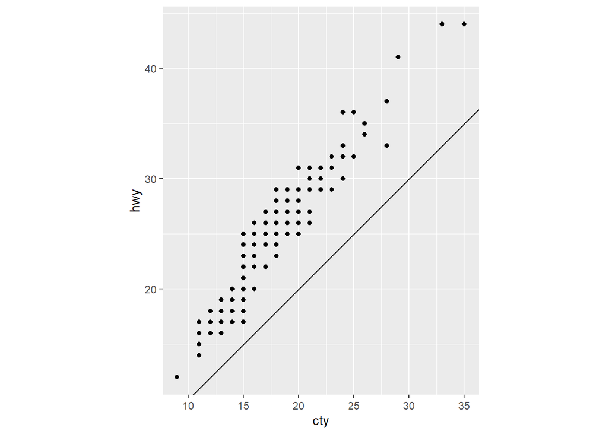

   ```r
   ggplot(data = mpg, mapping = aes(x = cty, y = hwy)) +
     geom_point() +
     geom_abline() +
     coord_fixed()
   ```

## Answer

**1**

> Turn a stacked bar chart into a pie chart using `coord_polar()`.

A pie chart is a stacked bar chart with the addition of polar coordinated, For example:

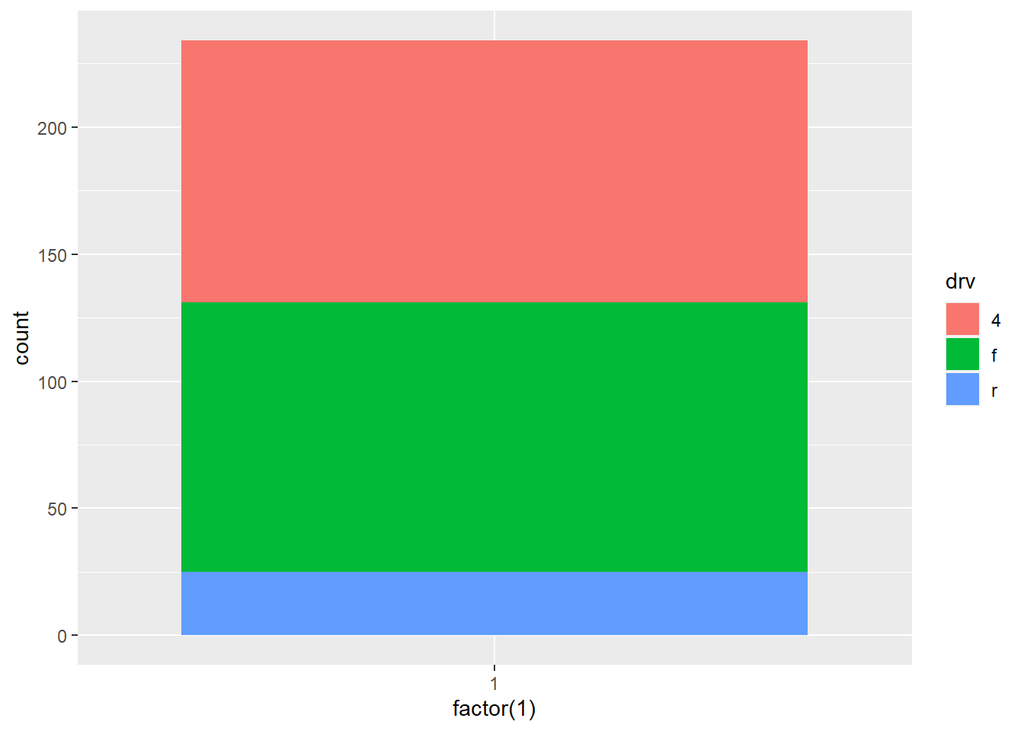

```r
ggplot(data = mpg, mapping = aes(x = factor(1), fill = drv)) +
  geom_bar()
```

Now add `coord_polar(theta = 'y')` to create pie chart

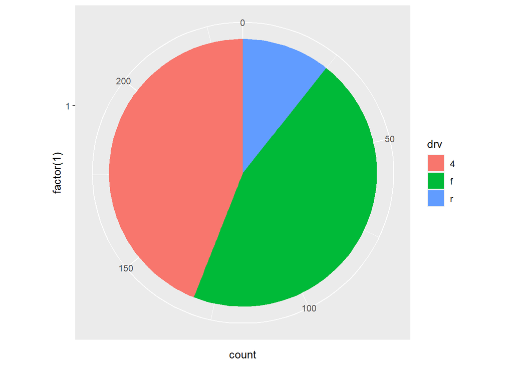

```r
ggplot(data = mpg, mapping = aes(x = factor(1), fill = drv)) +
  geom_bar() +
  coord_polar(theta = 'y')
```

The argument `theta = 'y'` maps `y` to the angle of each section. If `coord_polar()` is specified without `theta = 'y'`, then the resulting plot is called a bulls-eye chart

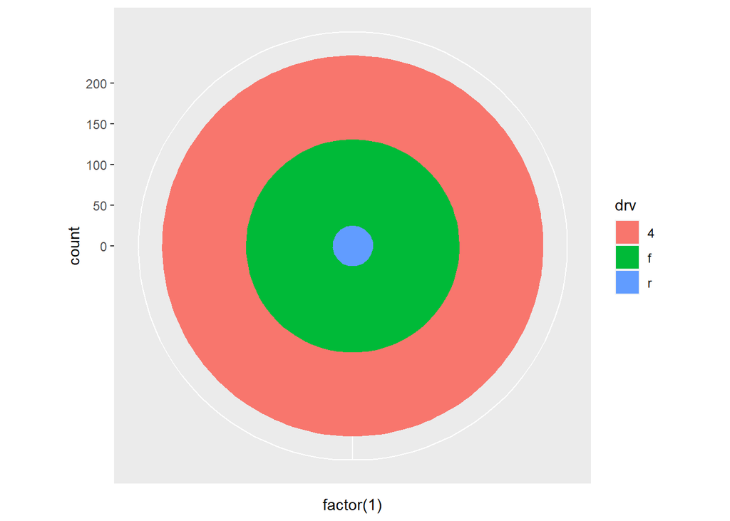

```r
ggplot(data = mpg, mapping = aes(x = factor(1), fill = drv)) +
  geom_bar(width = 1) +
  coord_polar()
```

**2**

> What does `labs()` do? Read the documentation.

The `labs()` function adds axis titles, plot titles, and a caption to the plot.

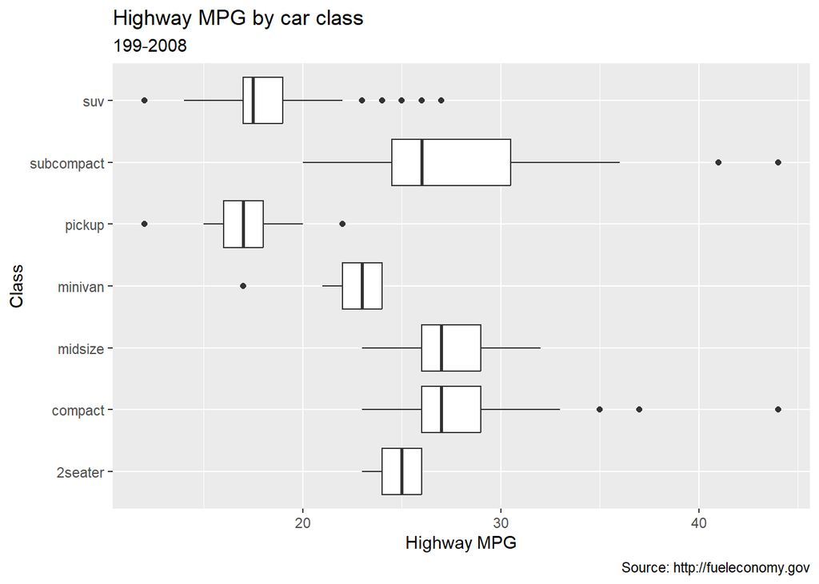

```r
ggplot(data = mpg, mapping = aes(x = class, y = hwy)) +
  geom_boxplot() +
  coord_flip() +
  labs(y = 'Highway MPG',
       x = "Class",
       title = "Highway MPG by car class",
       subtitle = '199-2008',
       caption = "Source: http://fueleconomy.gov"
       )
```

The arguments to `labs()` are optional, so we can add as many or as few of these as are needed

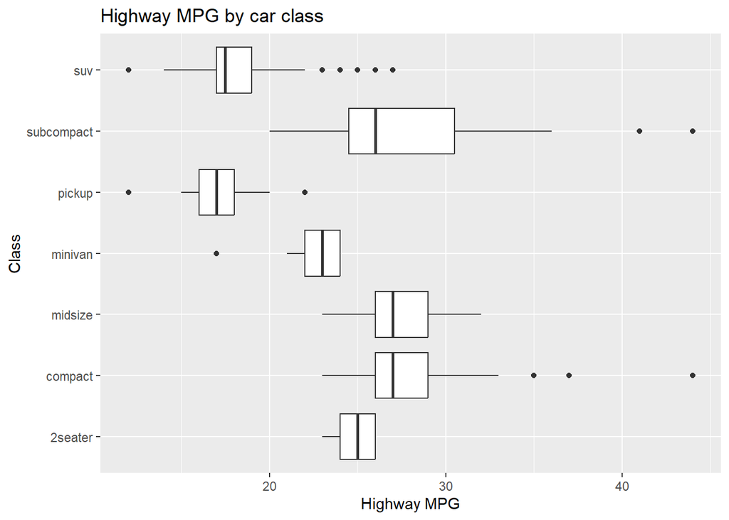

```r
ggplot(data = mpg, mapping = aes(x = class, y = hwy)) +
  geom_boxplot() +
  coord_flip() +
  labs(y = 'Highway MPG',
       x = "Class",
       title = "Highway MPG by car class",
       )
```

**3**

> What’s the difference between `coord_quickmap()` and `coord_map()`?

```r
?coord_map()
```

```
## starting httpd help server ... done
```

```r
?coord_quickmap()
```

The `coord_map()` function uses map projections to project the 3D Earth onto a 2D plane. By default, `coord_map()` uses the Mercator projection. This projection is applied to all the geoms in the plot. The `coord_quickmap()` function uses an approximate but faster map projection. This approximation ignores the curvature of Earth and adjusts the map for the latitude/longitude ratio. The `coord_quickmap()` project is faster then `coord_map()` both because the projection is computationally easier, and unlike `coord_map()`, the coordinates of the individual geoms do not need to be transformed.

**4**

> What does the following plot tell you about the relationship between city and highway mpg? Why is `coord_fixed()` important? What does `geom_abline()` do?

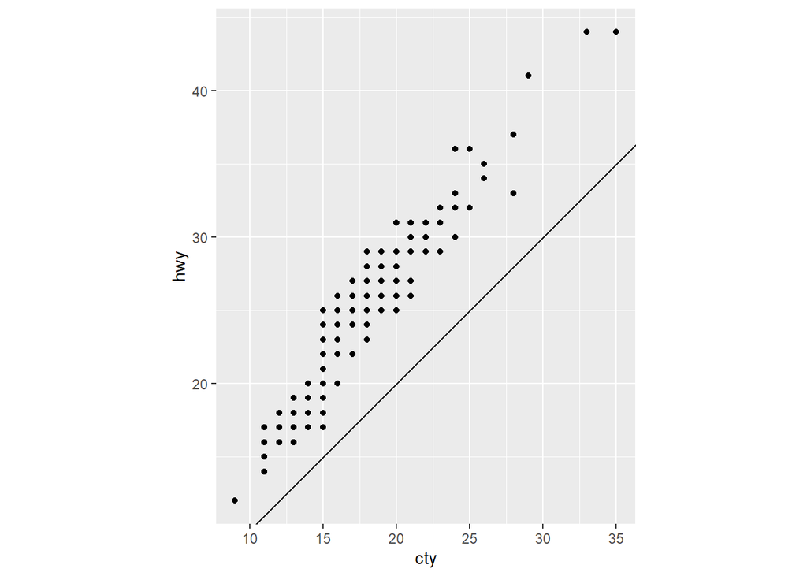

```r
p <- ggplot(data = mpg, mapping = aes(x = cty, y = hwy)) +
  geom_point() +
  geom_abline()

p +  coord_fixed()
```

If we did not include `coord_fixed()`, then the line would no longer have an angle of 45 degrees.

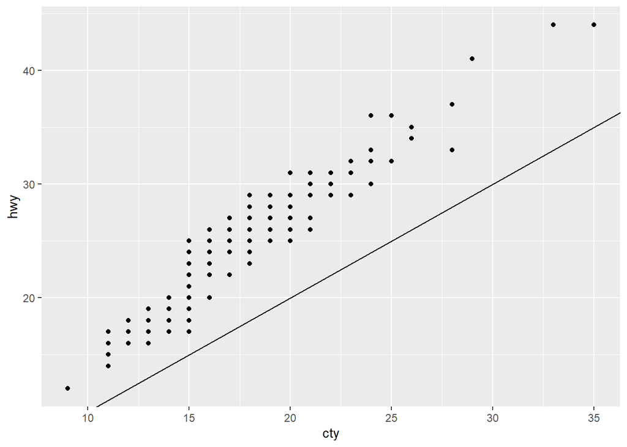

```r
p
```

On average, humans are best able to perceive difference in angles relative to 45 degrees. The Function ``ggthemes::bank_slopes()` will calculate the optimal aspect ratio to bank slopes to 45 degrees.